# Relationships between hospice- and palliative care-related Google search volumes and hospice utilization

Mihir Patel

#### Introduction

*Background*

Hospice care in the U.S. is growing, with a nearly sixfold increase in enrollees from 1994 to 2014 (Finnigan-Fox et al., 2017). Timely utilization of hospice is associated with effective pain management at the end of life, preservation of patient dignity, improved quality of life for patients, and decreased rates of depression and complicated bereavement for caregivers (Finnigan-Fox et al., 2017; Wright et al., 2008). However, an estimated 40% of eligible patients do not receive hospice care (Cagle et al., 2016), and racial minority populations (Hispanics and African Americans particularly) are underrepresented in the hospice patient distribution (Haas et al., 2007). Among key factors contributing to reluctance toward hospice utilization are insufficient knowledge about hospice services and misconceptions about hospice philosophy. These misconceptions include equating hospice with “giving up”, assuming hospice is only for the final weeks or days of life, assuming hospice disrupts ongoing patient-physician relationships, failing to realize that hospice cannot provide concurrent curative care, among others (Cagle et al., 2016; Mrig & Spencer, 2018; Shalev et al., 2019; Vig et al., 2010). Hence, understanding the strategies that patients and caregivers use to learn about hospice is a necessary step toward promoting timely hospice utilization.

Recently, individuals are increasingly utilizing the Internet as a resource for obtaining health and healthcare information, given the easily accessible and ubiquitous nature of websites and a constantly updated variety of published content. Among respondents in one national survey, 81% of adults reported Internet use, and 72% of those respondents reported seeking health information online. Although Internet use generally declines with age, those age 65 or older represent the fastest growing population of Internet users (Fischer et al., 2014). While the Internet commonly functions as a secondary or tertiary source of health information behind healthcare professionals and family or friends for older adults (Fischer et al., 2014; Magsamen-Conrad et al., 2019), it is plausible that patients and caregivers routinely utilize online resources when seeking information about hospice. The breadth of hospice-related information available online corroborates this notion (Corn et al., 2011; Finnigan-Fox et al., 2017).

The current landscape for the integration of web-based resources in patient care warrants exploration of the relationship between Internet search volume for hospice- and palliative care-related terms and hospice utilization. Understanding disparities in access to or willingness to pursue online information about hospice could reveal new insights about and help address disparities in hospice utilization.

*Objective and hypotheses*

Here I explore trends in Google search volumes for hospice- and palliative care-related search terms across U.S. states, relationships between said search volumes and the normalized number of hospice users across regions and the aggregate U.S., and relationships between said search volumes and mean per-patient hospice length of stay (LOS) across the same geographical distribution. Although hospice and palliative care differ in that palliative care involves symptom management concurrent with curative treatment while hospice is provided in the last six months of life post-treatment termination (Shalev et al., 2019), I exploratorily included search terms for both in this study. Given the aforementioned connection between health information-seeking behaviors and healthcare utilization, I hypothesized that search volumes for hospice- and palliative care-related search terms would be positively and reciprocally associated with hospice utilization and mean LOS and that these associations would be more pronounced in areas of greater hospice utilization.

#### Materials and Methods

*Google search terms and volumes*

To obtain Google search volumes for hospice- and palliative care-related search terms, I accessed Google Trends via the gtrendsR package (v1.4.7) in R (v4.0.2). Google Trends provides search volumes, based on the number of searches for a given term normalized to the total number of searches in a geographic area during a specified time frame. These indices are then relativized to the highest measured volume across the time frame and presented on a 0-100 scale (Bail et al., 2018; Dreher et al., 2018; Effenberger et al., 2020). Search terms included “hospice”, “hospice care”, “home hospice”, “palliative care”, and “palliative”, which were among the most popular terms related to hospice and palliative care across U.S. states based on Google Trends data and in previous studies, such as Finnigan-Fox et al. (2017). For each year (defined as from January 1 to December 31) individually from 2014 to 2018, I made separate calls to the Google Trends database using the gtrends() function. In each call, I queried for all five search terms together, specified “web” as the Google product to query, and limited search results to the geographic U.S. and to the default U.S. English setting. I collected search volumes across each state and District of Columbia for each search term. When search volume levels were unavailable for a minority of states (i.e., Alaska, North Dakota, and Wyoming in the case of “home hospice” only), they were considered negligible and treated as 0.

*Hospice utilization*

As measures of hospice utilization, I collected data regarding the number of Medicare hospice beneficiaries and mean per-patient hospice LOS (the total number of covered days on hospice divided by the number of hospice beneficiaries) for each state and District of Columbia from 2014 to 2018. For 2014 to 2016, these data were available in the Centers for Medicare & Medicaid Services (CMS) Hospice Utilization and Payment Public Use Files for each year, archived under the Hospice Providers subsection of the Legacy Medicare Provider Utilization and Payment dataset series. For 2017 and 2018, these data were filed as Medicare Hospice Utilization by State datasets under the Medicare Utilization for Part A archive. Since normalization of hospice user count based on Medicare beneficiary count was necessary, I obtained the total number of Original Medicare (i.e., non-Medicare Advantage) enrollees for each state and District of Columbia from 2014 to 2018 via the Kaiser Family Foundation (KFF) Total Number of Medicare Beneficiaries dataset.

*Race and socioeconomic status (SES)*

Race and SES have been implicated as social determinants of hospice utilization. Specifically, racial and ethnic minorities and individuals with lower SES exhibit a lower likelihood of hospice utilization (Haas et al., 2007). To account for variations in hospice utilization and search volumes for hospice- and palliative care-related terms due to race and SES, I collected data on racial composition and the median household income for each state and District of Columbia. For the former, I obtained the proportion of Caucasian individuals for each location and year from 2014 to 2018 via the KFF Population Distribution by Race/Ethnicity dataset. For the latter, I collected median household incomes for the same duration based on 2018 U.S. dollars from the U.S. Bureau of Census Current Population Survey Annual Social and Economic (ASEC) Supplement for 2019.

*Internet penetration rates*

Additionally, Internet access is associated with greater health literacy (Bailey et al., 2015), while disparities or disruptions in Internet access are associated with decreased online health information-seeking behaviors (McCloud et al., 2016). Hence, to account for the likelihood of higher search volumes in areas of higher Internet penetration rates (Bail et al., 2018), I collected data regarding the proportion of households with Internet access in each state and District of Columbia from the National Center for Education Services (NCES) Digest of Education Statistics subsection of their Annual Reports. These data span 2015 to 2018 (data from 2014 were unavailable). Households were characterized as having Internet access if residents could access the Internet at home via paid subscription to a mobile device-based cellular data plan; broadband Internet service installed via cable, fiber optic, or digital subscriber line; satellite Internet service; dial-up Internet service; or other service.

*Geographical categorization*

I associated each state and District of Columbia to their corresponding U.S. Census Bureau-designated region (Northeast, Midwest, South, or West). For the generation of map diagrams, I retrieved Federal Information Processing Standards (FIPS) codes for each state and District of Columbia via the usmap package (v0.5.1) in R.

*Data pre-processing*

Both Medicare hospice user and total Medicare beneficiary data were skewed right. To generate more normal distributions, I log-transformed these data. Other variables were normal and did not necessitate transformation.

*Estimation strategy*

For the analysis of each of the following relationships, I generated separate ordinary least-squares multiple linear regression models for each region and combinatorially for each of the five search terms. Regression coefficients in all models were standardized by z-score using the lm.beta package (v1.5.1) in R. First, I generated a set of models predicting the log-transformed number of Medicare hospice users as a function of the search volume for a given term. Covariates included the log-transformed number of Medicare beneficiaries, the proportion of Caucasian individuals in state populations, and state median household incomes. Second, I queried the inverse relationship, predicting search volume for a given term based on the log-transformed number of Medicare hospice users. Covariates for this model included the log-transformed number of Medicare beneficiaries, the proportion of Caucasian individuals in state populations, state median household incomes, and state household Internet access rates. Third, I generated a set of models predicting the mean per-patient hospice LOS as a function of the search volume for a given term. Covariates included the log-transformed number of Medicare hospice users, the log-transformed number of Medicare beneficiaries, the proportion of Caucasian individuals in state populations, and state median household incomes. Fourth, I queried the inverse relationship, predicting search volume for a given term based on the mean per-patient hospice LOS. Covariates in this model included the log-transformed number of Medicare hospice users, the log-transformed number of Medicare beneficiaries, the proportion of Caucasian individuals in state populations, state median household incomes, and state household Internet access rates.

While log-transformation of certain data obfuscates determination of effect sizes, these models still provide insight into the general positive or negative directionality of queried relationships.

#### Results

*Trends in search volume for hospice- and palliative care-related terms*

*Predicting hospice utilization from search volumes*

*Predicting search volumes from hospice utilization*

To examine the inverse effect of hospice utilization on search volumes for hospice- and palliative care-related terms, I generated the linear regression models summarized in Fig. 4. Log-transformed hospice user count did not have a statistically significant association with search volume for any term.

*Predicting mean per-patient hospice LOS from search volumes*

Further, in all models, both Caucasian proportion and median household income had significant negative associations (p < 0.01 in most cases) with mean LOS in all regions, including the aggregate U.S., except the Northeast. This may further corroborate delays in hospice utilization as a result of financial flexibility.

*Predicting search volumes from mean per-patient hospice LOS*

To examine the inverse effect of mean per-patient LOS on search volumes, I generated the linear regression models summarized in Fig. 6. Among hospice-related terms, mean LOS had positive, statistically significant associations with volume for only “hospice” and “home hospice” for the West and U.S. (p < 0.01 in all cases, except p < 0.05 for “hospice” in the West), but not for other locations. Among palliative care-related terms, mean LOS had a negative association (p < 0.05) with volume for “palliative” in the Midwest and U.S.

#### Discussion

Nonetheless, this study has several limitations. First, Google Trends does not provide absolute search volumes. This limits the interpretability of search volume patterns longitudinally, as changes for states treated as the point of reference in a given time range may be more dramatic than they really are. Albeit less accessible, one useful alternative that warrants consideration in future investigations is Google AdWords, which reports average monthly search volumes for specified terms. Albeit reported as monthly averages in the form of 10-point ranges, these volumes represent absolute levels. Additional benefits of Google AdWords include the availability search volumes for low-frequency search terms, which Google Trends often does not, and the availability of search volumes at city and county levels. Lastly, Google AdWords provides search volume results from not only Google, but also other leading Internet search engines (Bail et al., 2018).

A second limitation pertains to algorithmic confounding: search algorithms are not static, and changes therein may influence the reliability of data derived from said algorithms. (Lazer et al., 2014). Of note, Google Trends introduced an improvement to their data collection system on January 1, 2016. It is possible that this update disproportionately impacted search volume levels for lower-frequency search terms, such as “home hospice”. Separately, an inability to capture user intention when performing searches may skew a minority of search result data. Because the Google search algorithm provides autocompleted search suggestions when users begin typing search queries (Bail et al., 2018), it remains possible that some queries may be misleading (e.g., inadvertently searching “hospice care” when “hospice” was intended, searching “palliative care” when “palliative” was intended, or conflating “home hospice” and “home health”). Although this possibility cannot be readily accounted for, the search terms included in this study were general, reducing the possibility of variability in specific search suggestions based on user demographic characteristics or search history.

A third limitation pertains to an inability to rigorously assess temporality in the relationships between search volume and hospice utilization. Despite aforementioned results, it remains unclear whether searches for hospice- or palliative care-related terms precede or follow the onset of hospice utilization (i.e., it is possible that prospective or pre-contemplative hospice patients or caregivers search for said terms to learn more about hospice prior to onboarding or that patients or caregivers already enrolled in hospice search for said terms). One method to address this limitation in future investigations involves employing Google AdWords to query low-frequency search terms that may indicate temporality, such as “how to enroll in hospice” or “starting hospice”. Further, the applicability of online behaviors to offline actions remains unverified (Bail, 2014; Golder & Macy, 2014), especially considering that user characteristics are unknown. Searching for hospice- or palliative care-related information does not guarantee access to reliable sources of information (Corn et al., 2011; Finnigan-Fox et al., 2017), limiting the generalizability of discussed relationships. Searching for information alone does not account for the impacts of Internet skill and health literacy on health information-seeking behaviors (Jacobs et al., 2017; McCloud et al., 2016); hence, integration of these data into models is warranted in future investigations.

Despite these limitations, these results suggest that, to some degree, variability in Internet search volumes for hospice- and palliative care-related terms can elucidate disparities in hospice utilization. These digital trace data can be helpful in identifying areas where health information-seeking behaviors regarding hospice lag and potentially conduce to clinical interventions to increase patient and caregiver agency in pursuing hospice-related information online in addition to their Internet skill and hospice-related health literacy. Proximately, clinicians should be encouraged to connect patients and caregivers with reliable online sources of information about hospice.

#### Figures and Tables

| Region | Year | Number of Medicare hospice users | Number of Medicare beneficiaries | Mean per-patient hospice LOS | % Caucasian | Median household income | % of households with internet access | “Hospice” search volume | “Hospice care” search volume | “Home hospice” search volume | “Palliative care” search volume | “Palliative” search volume |
| --- | --- | --- | --- | --- | --- | --- | --- | --- | --- | --- | --- | --- |
| Midwest | 2014 | 26414.67 | 700487.9 | 62.25000 | 79.89167 | 59145.92 | NA | 69.75000 | 66.08333 | 28.00000 | 45.50000 | 62.08333 |
| Midwest | 2015 | 27379.50 | 703292.9 | 61.75000 | 79.47500 | 61114.50 | 76.77104 | 72.25000 | 63.16667 | 28.33333 | 67.50000 | 66.50000 |
| Midwest | 2016 | 28196.83 | 721959.5 | 62.75000 | 79.20000 | 61114.50 | 81.35707 | 71.00000 | 64.50000 | 32.91667 | 63.50000 | 69.25000 |
| Midwest | 2017 | 29570.50 | 722364.5 | 62.33333 | 78.73333 | 62398.08 | 83.14537 | 78.41667 | 54.50000 | 28.83333 | 60.75000 | 66.75000 |
| Midwest | 2018 | 30622.33 | 743275.4 | 64.58333 | 78.31667 | 64540.83 | 84.30274 | 77.41667 | 57.66667 | 27.25000 | 70.75000 | 70.58333 |
| Northeast | 2014 | 22604.44 | 772961.7 | 57.66667 | 76.30000 | 65176.56 | NA | 62.55556 | 73.22222 | 50.11111 | 52.77778 | 65.55556 |
| Northeast | 2015 | 23393.67 | 781461.4 | 57.66667 | 75.85556 | 67024.33 | 80.63928 | 64.11111 | 65.44444 | 50.66667 | 80.00000 | 75.66667 |
| Northeast | 2016 | 23928.89 | 797156.1 | 59.55556 | 75.53333 | 67024.33 | 83.42654 | 66.88889 | 76.66667 | 54.11111 | 75.22222 | 81.77778 |
| Northeast | 2017 | 24850.33 | 790873.6 | 60.55556 | 74.98889 | 68437.67 | 84.93527 | 70.11111 | 64.00000 | 45.66667 | 69.11111 | 75.55556 |
| Northeast | 2018 | 25455.22 | 602636.0 | 61.88889 | 74.60000 | 70830.22 | 86.42224 | 67.77778 | 62.55556 | 41.44444 | 74.44444 | 77.11111 |
| South | 2014 | 31390.59 | 848330.1 | 72.94118 | 63.21765 | 52948.06 | NA | 75.76471 | 69.70588 | 31.05882 | 36.94118 | 51.82353 |
| South | 2015 | 32896.06 | 856787.4 | 72.70588 | 62.87647 | 54180.53 | 72.94575 | 80.23529 | 68.29412 | 31.76471 | 61.00000 | 56.88235 |
| South | 2016 | 34057.35 | 877501.9 | 72.88235 | 62.62941 | 54180.53 | 78.44511 | 80.11765 | 72.47059 | 36.17647 | 55.23529 | 62.11765 |
| South | 2017 | 35679.29 | 878372.5 | 73.23529 | 62.26471 | 58308.53 | 80.62861 | 83.41176 | 63.05882 | 30.94118 | 54.58824 | 59.00000 |
| South | 2018 | 37302.47 | 914326.9 | 75.00000 | 62.01176 | 59017.18 | 82.83514 | 83.64706 | 62.58824 | 28.82353 | 59.05882 | 61.94118 |
| West | 2014 | 20295.85 | 540833.5 | 66.46154 | 62.95385 | 61061.69 | NA | 61.69231 | 51.76923 | 29.38462 | 36.46154 | 49.46154 |
| West | 2015 | 21344.00 | 557893.2 | 66.00000 | 62.60769 | 63391.31 | 79.71369 | 63.00000 | 52.15385 | 32.23077 | 57.30769 | 54.23077 |
| West | 2016 | 22328.46 | 578031.3 | 66.84615 | 62.33846 | 63391.31 | 83.44137 | 63.61538 | 57.46154 | 35.00000 | 56.38462 | 60.23077 |
| West | 2017 | 23536.23 | 590977.4 | 67.76923 | 61.84615 | 66485.77 | 85.02407 | 69.30769 | 47.23077 | 34.07692 | 48.61538 | 52.38462 |
| West | 2018 | 24627.77 | 630265.5 | 70.38462 | 61.43077 | 66899.92 | 86.72051 | 67.23077 | 47.07692 | 29.84615 | 55.46154 | 62.38462 |
| U.S. | 2014 | 25841.22 | 721861.9 | 66.07843 | 69.38235 | 58632.53 | NA | 68.43137 | 64.90196 | 33.27451 | 41.62745 | 56.05882 |
| U.S. | 2015 | 26976.51 | 731189.5 | 65.76471 | 69.00392 | 60426.45 | 76.92866 | 71.11765 | 62.47059 | 34.41176 | 64.94118 | 61.78431 |
| U.S. | 2016 | 27901.31 | 750389.4 | 66.60784 | 68.73137 | 60426.45 | 81.28291 | 71.43137 | 67.50980 | 38.27451 | 61.00000 | 66.78431 |
| U.S. | 2017 | 29235.65 | 752966.2 | 67.03922 | 68.27843 | 63142.67 | 83.10120 | 76.29412 | 57.17647 | 33.84314 | 57.07843 | 62.05882 |
| U.S. | 2018 | 30409.18 | 746667.4 | 69.05882 | 67.92157 | 64410.84 | 84.80386 | 75.19608 | 57.47059 | 30.94118 | 63.60784 | 66.76471 |

**Table 1:** Mean values for all variables categorized by year and by region or aggregately for the U.S.

[figure not shown]

**Fig. 1:** Relative Google search volume for hospice care-related terms across US states from 2014 to 2018. Search volumes shown for (A) “hospice”, (B) “hospice care”, and (C) “home hospice”.

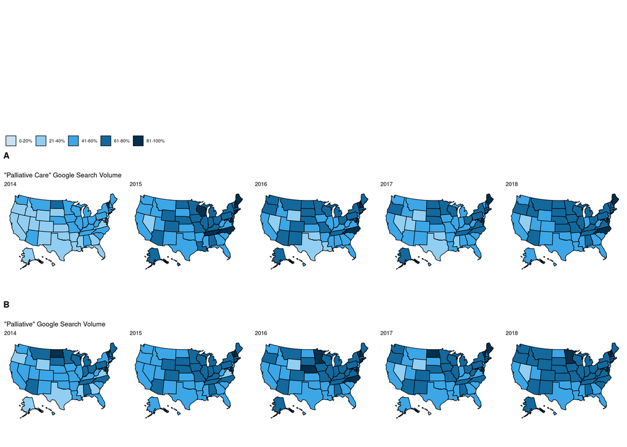

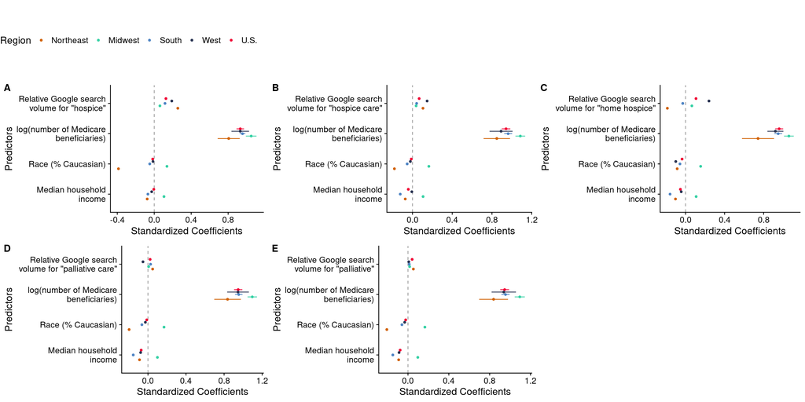

**Fig. 3:** Standardized coefficients from ordinary least-squares linear regression model predicting number of hospice users (log-transformed) based on relative Google search volume for hospice- or palliative care-related terms across US states from 2014 to 2018. Covariates include number of Medicare beneficiaries (log-transformed), race (% Caucasian), and median household income for each state. Results are categorized per region and aggregately for the U.S. Dots representing standardized coefficients are depicted with 95% confidence intervals. Search terms include (A) “hospice”, (B) “hospice care”, (C) “home hospice”, (D) “palliative care”, and (E) “palliative”.

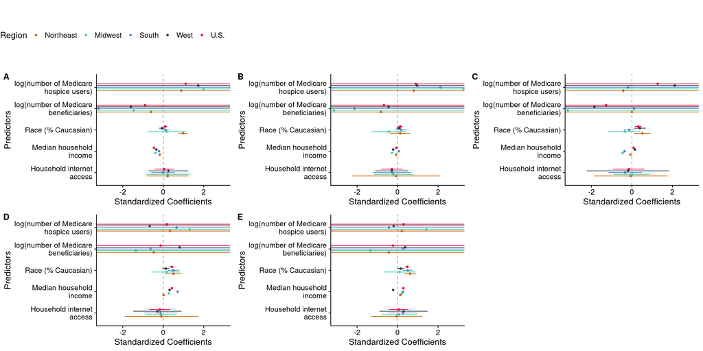

**Fig. 4:** Standardized coefficients from ordinary least-squares linear regression model predicting relative Google search volume for hospice- or palliative care-related terms across US states from 2015 to 2018 based on number of Medicare hospice users (log-transformed). Covariates include number of Medicare beneficiaries (log-transformed), race (% Caucasian), median household income, and internet penetration rate (% of households with internet access) for each state. Results are categorized per region and aggregately for the U.S. Dots representing standardized coefficients are depicted with 95% confidence intervals. Search terms predicted include (A) “hospice”, (B) “hospice care”, (C) “home hospice”, (D) “palliative care”, and (E) “palliative”. The scale for standardized coefficients has been abbreviated to enhance resolution; however, some confidence intervals may extend beyond these limits.

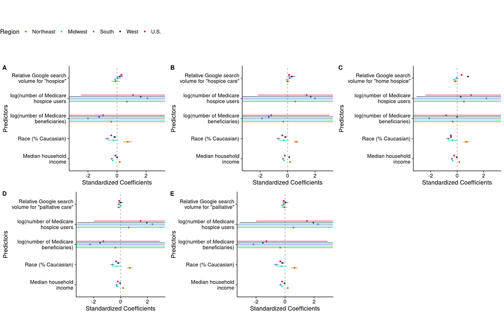

**Fig. 5:** Standardized coefficients from ordinary least-squares linear regression model predicting mean per-patient hospice length of stay based on relative Google search volume for hospice- or palliative care-related terms across US states from 2014 to 2018. Covariates include number of Medicare hospice users (log-transformed), number of Medicare beneficiaries (log-transformed), race (% Caucasian), and median household income for each state. Results are categorized per region and aggregately for the U.S. Dots representing standardized coefficients are depicted with 95% confidence intervals. Search terms include (A) “hospice”, (B) “hospice care”, (C) “home hospice”, (D) “palliative care”, and (E) “palliative”. The scale for standardized coefficients has been abbreviated to enhance resolution; however, some confidence intervals may extend beyond these limits.

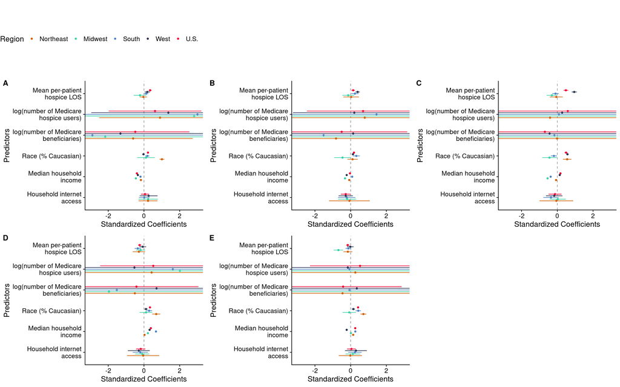

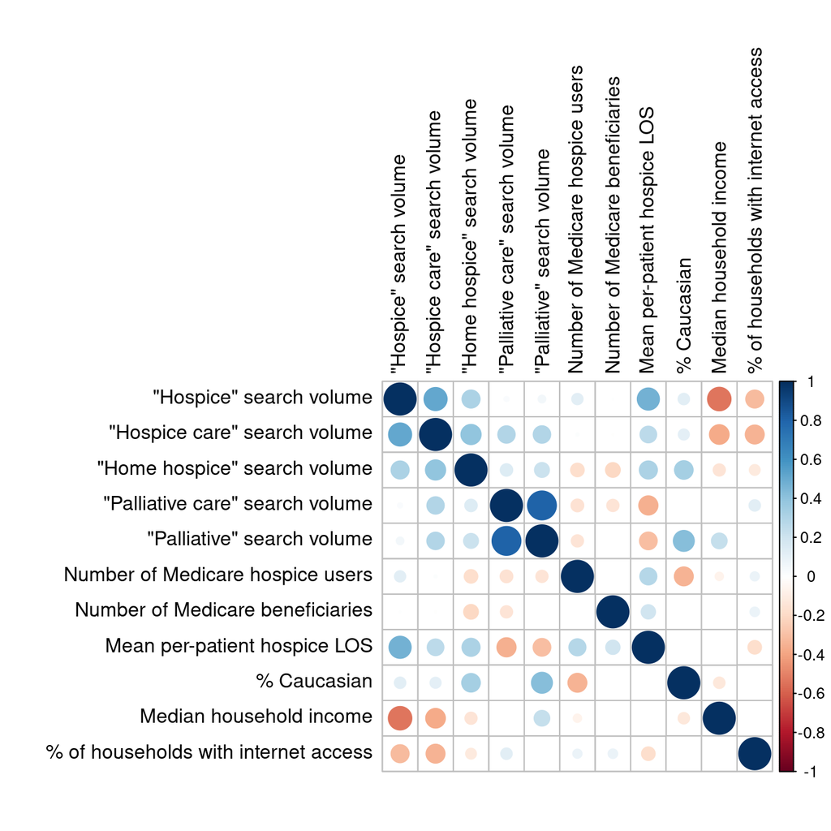

**Fig. 7:** Correlation matrix of all variables. All variables are aggregated from state-level data from 2014 to 2018 (internet penetration data are from 2015 to 2018). Blue values indicate a positive relationship, while red values indicate a negative relationship. The size of each circle represents the magnitude of the Pearson correlation coefficient. Relationships shown are statistically significant (*p* < 0.05); blank spaces represent insignificant relationships.

#### References

Bail, C. A. (2014). The cultural environment: Measuring culture with big data. Theory and Society, 43(3-4), 465-482. doi:10.1007/s11186-014-9216-5

Bail, C. A., Merhout, F., & Ding, P. (2018). Using internet search data to examine the relationship between anti-muslim and pro-ISIS sentiment in U.S. counties. Science Advances, 4(6), eaao5948-eaao5948. doi:10.1126/sciadv.aao5948

Bailey, S. C., O’Conor, R., Bojarski, E. A., Mullen, R., Patzer, R. E., Vicencio, D., . . . Wolf, M. S. (2015). Literacy disparities in patient access and health-related use of internet and mobile technologies. Health Expectations : An International Journal of Public Participation in Health Care and Health Policy, 18(6), 3079-3087. doi:10.1111/hex.12294

Cagle, J. G., Van Dussen, D. J., Culler, K. L., Carrion, I., Hong, S., Guralnik, J., & Zimmerman, S. (2016). Knowledge about hospice: Exploring misconceptions, attitudes, and preferences for care. American Journal of Hospice & Palliative Medicine, 33(1), 27-33. doi:10.1177/1049909114546885

Corn, M., MD, Gustafson, D. H., PhD, Harris, L. M., PhD, Kutner, Jean S., MD, MSPH, McFarren, A. E., RN, & Shad, A. T., MD. (2011). Survey of consumer informatics for palliation and hospice care. American Journal of Preventive Medicine, 40(5), S173-S178. doi:10.1016/j.amepre.2011.01.015

Dreher, P. C., Tong, C., Ghiraldi, E., & Friedlander, J. I. (2018). Use of google trends to track online behavior and interest in kidney stone surgery. Urology (Ridgewood, N.J.), 121, 74-78. doi:10.1016/j.urology.2018.05.040

Effenberger, M., Kronbichler, A., Shin, J. I., Mayer, G., Tilg, H., & Perco, P. (2020). Association of the COVID-19 pandemic with internet search volumes: A google TrendsTM analysis. International Journal of Infectious Diseases, 95, 192-197. doi:10.1016/j.ijid.2020.04.033

Finnigan-Fox, G., Matlock, D. D., Tate, C. E., Knoepke, C. E., & Allen, L. A. (2017). Hospice, she yelped: Examining the quantity and quality of decision support available to patient and families considering hospice. Journal of Pain and Symptom Management, 54(6), 916-921.e1. doi:10.1016/j.jpainsymman.2017.08.002

Fischer, S. H., David, D., Crotty, B. H., Dierks, M., & Safran, C. (2014). Acceptance and use of health information technology by community-dwelling elders. International Journal of Medical Informatics (Shannon, Ireland), 83(9), 624-635. doi:10.1016/j.ijmedinf.2014.06.005

Golder, S. A., & Macy, M. W. (2014). Digital footprints: Opportunities and challenges for online social research. Annual Review of Sociology, 40(1), 129-152. doi:10.1146/annurev-soc-071913-043145

Haas, J. S., Earle, C. C., Orav, J. E., Brawarsky, P., Neville, B. A., Acevedo-Garcia, D., & Williams, D. R. (2007). Lower use of hospice by cancer patients who live in minority versus white areas. Journal of General Internal Medicine : JGIM, 22(3), 396-399. doi:10.1007/s11606-006-0034-y

Jacobs, W., Amuta, A. O., & Jeon, K. C. (2017). Health information seeking in the digital age: An analysis of health information seeking behavior among US adults. Cogent Social Sciences, 3(1) doi:10.1080/23311886.2017.1302785

Lazer, D., Kennedy, R., King, G., & Vespignani, A. (2014). The parable of google flu: Traps in big data analysis. Science (American Association for the Advancement of Science), 343(6176), 1203-1205. doi:10.1126/science.1248506

Magsamen-Conrad, K., Dillon, J. M., Billotte Verhoff, C., & Faulkner, S. L. (2018;2019;). Online health-information seeking among older populations: Family influences and the role of the medical professional. Health Communication, 34(8), 859-871. doi:10.1080/10410236.2018.1439265

McCloud, R. F., Okechukwu, C. A., Sorensen, G., & Viswanath, K. (2016). Beyond access: Barriers to internet health information seeking among the urban poor. Journal of the American Medical Informatics Association : JAMIA, 23(6), 1053-1059. doi:10.1093/jamia/ocv204

Mrig, E. H., & Spencer, K. L. (2018). Political economy of hope as a cultural facet of biomedicalization: A qualitative examination of constraints to hospice utilization among U.S. end-stage cancer patients. Social Science & Medicine (1982), 200, 107-113. doi:10.1016/j.socscimed.2018.01.033

Shalev, A., Phongtankuel, V., Kozlov, E., Shen, M. J., Adelman, R. D., & Reid, M. C. (2017;2018;). Awareness and misperceptions of hospice and palliative care: A population-based survey study. American Journal of Hospice & Palliative Medicine, 35(3), 431-439. doi:10.1177/1049909117715215

Vig, E. K., Starks, H., Taylor, J. S., Hopley, E. K., & Fryer-Edwards, K. (2010). Why Don’t patients enroll in hospice? can we do anything about it? Journal of General Internal Medicine : JGIM, 25(10), 1009-1019. doi:10.1007/s11606-010-1423-9

Wang, S., Hsu, S. H., Aldridge, M. D., Cherlin, E., & Bradley, E. (2019). Racial differences in health care transitions and hospice use at the end of life. Journal of Palliative Medicine, 22(6), 619-627. doi:10.1089/jpm.2018.0436

Wright, A. A., Zhang, B., Ray, A., Mack, J. W., Trice, E., Balboni, T., . . . Prigerson, H. G. (2008). Associations between end-of-life discussions, patient mental health, medical care near death, and caregiver bereavement adjustment. JAMA : The Journal of the American Medical Association, 300(14), 1665-1673. doi:10.1001/jama.300.14.1665